```python
import pandas as pd
import numpy as np
import matplotlib.pyplot as plt

from sklearn.neighbors import KNeighborsClassifier
from sklearn.neighbors import KNeighborsRegressor

from sklearn.model_selection import train_test_split
from sklearn.model_selection import cross_val_score
from sklearn.model_selection import RepeatedKFold
from sklearn.model_selection import KFold
from sklearn.model_selection import StratifiedKFold
from sklearn.model_selection import GridSearchCV

from sklearn.linear_model import LinearRegression
from sklearn.linear_model import Lasso
from sklearn.linear_model import Ridge
from sklearn.linear_model import LogisticRegression

from sklearn import preprocessing

from sklearn.pipeline import Pipeline


# read in data...We will clean it up into X, y below
data= pd.read_csv("https://vincentarelbundock.github.io/Rdatasets/csv/Ecdat/Caschool.csv")
data.head()
```

|  | Unnamed: 0 | distcod | county | district | grspan | enrltot | teachers | calwpct | mealpct | computer | testscr | compstu | expnstu | str | avginc | elpct | readscr | mathscr |
| --- | --- | --- | --- | --- | --- | --- | --- | --- | --- | --- | --- | --- | --- | --- | --- | --- | --- | --- |
| 0 | 1 | 75119 | Alameda | Sunol Glen Unified | KK-08 | 195 | 10.900000 | 0.510200 | 2.040800 | 67 | 690.799988 | 0.343590 | 6384.911133 | 17.889910 | 22.690001 | 0.000000 | 691.599976 | 690.000000 |
| 1 | 2 | 61499 | Butte | Manzanita Elementary | KK-08 | 240 | 11.150000 | 15.416700 | 47.916698 | 101 | 661.200012 | 0.420833 | 5099.380859 | 21.524664 | 9.824000 | 4.583333 | 660.500000 | 661.900024 |
| 2 | 3 | 61549 | Butte | Thermalito Union Elementary | KK-08 | 1550 | 82.900002 | 55.032299 | 76.322601 | 169 | 643.599976 | 0.109032 | 5501.954590 | 18.697226 | 8.978000 | 30.000002 | 636.299988 | 650.900024 |
| 3 | 4 | 61457 | Butte | Golden Feather Union Elementary | KK-08 | 243 | 14.000000 | 36.475399 | 77.049202 | 85 | 647.700012 | 0.349794 | 7101.831055 | 17.357143 | 8.978000 | 0.000000 | 651.900024 | 643.500000 |
| 4 | 5 | 61523 | Butte | Palermo Union Elementary | KK-08 | 1335 | 71.500000 | 33.108601 | 78.427002 | 171 | 640.849976 | 0.128090 | 5235.987793 | 18.671329 | 9.080333 | 13.857677 | 641.799988 | 639.900024 |

# Q1.1

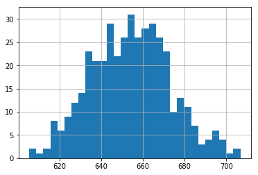

```python
# avg test score
plt.figure()
data['testscr'].hist(bins = 30)
plt.show()
```

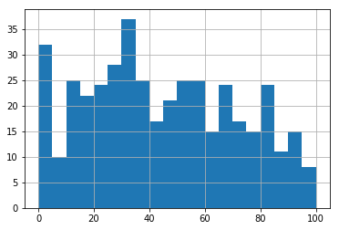

```python
# percent qualifying for reduced-price lunch
plt.figure()
data["mealpct"].hist(bins = 20)
plt.show()
```

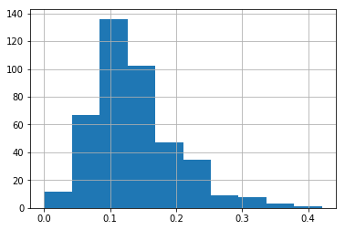

```python
# avg reading score
plt.figure()
data["compstu"].hist()
plt.show()
```

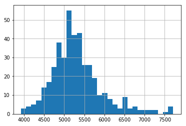

```python
# avg math score
plt.figure()
data["expnstu"].hist(bins = 30)
plt.show()
```

# Q1.2

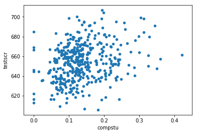

```python
# scatter plot of test score and avg math score
data.plot(kind = "scatter", x = "compstu", y = "testscr")
plt.show()
```

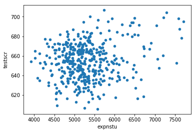

```python
# scatter plot of test score and avg reading score
data.plot(kind = "scatter", x = "expnstu", y = "testscr")
plt.show()
```

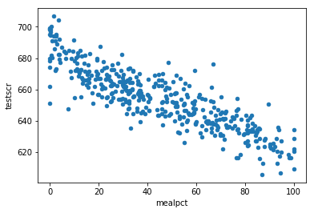

```python
# scatter plot of test score and percent qualifying for reduced-price lunch
data.plot(kind = "scatter", x = "mealpct", y = "testscr")
plt.show()
```

# Q1.3 and 1.4

```python
data.head()
## Preparing X and y
y = data.loc[:, data.columns == 'testscr']
X = data.loc[:, ['enrltot', 'calwpct', 'mealpct', 'compstu', 'expnstu', 'str', 'avginc', 'elpct']]
X_train, X_test, y_train, y_test = train_test_split(X, y,random_state = 1)

# We scale data here for later use
scaler = preprocessing.StandardScaler()
scaler.fit(X_train)
X_train_scaled = scaler.transform(X_train)
X_test_scaled = scaler.transform(X_test)
```

In this example each model is run with both scaled and unscaled data, seperately. Though this is not strictly required for every model.

OLS method

```python
# OLS on unscaled data
import statsmodels.api as sm
X_train_new = sm.add_constant(X_train)
model = sm.OLS(y_train, X_train_new).fit()
print(model.summary()) # get a complete summary of the model
X_test_new = sm.add_constant(X_test)
prey = model.predict(X_test_new)
```

```
                            OLS Regression Results
==============================================================================
Dep. Variable:                testscr   R-squared:                       0.832
Model:                            OLS   Adj. R-squared:                  0.827
Method:                 Least Squares   F-statistic:                     189.0
Date:                Tue, 16 Oct 2018   Prob (F-statistic):          1.43e-113
Time:                        09:49:04   Log-Likelihood:                -1086.0
No. Observations:                 315   AIC:                             2190.
Df Residuals:                     306   BIC:                             2224.
Df Model:                           8
Covariance Type:            nonrobust
==============================================================================
                 coef    std err          t      P>|t|      [0.025      0.975]
------------------------------------------------------------------------------
const        658.7748      9.962     66.132      0.000     639.173     678.377
enrltot     8.169e-06      0.000      0.062      0.950      -0.000       0.000
calwpct       -0.0855      0.063     -1.355      0.177      -0.210       0.039
mealpct       -0.3860      0.039    -10.003      0.000      -0.462      -0.310
compstu        9.3948      7.188      1.307      0.192      -4.750      23.539
expnstu        0.0020      0.001      2.007      0.046    3.88e-05       0.004
str           -0.1540      0.310     -0.496      0.620      -0.764       0.457
avginc         0.5424      0.098      5.544      0.000       0.350       0.735
elpct         -0.2119      0.037     -5.786      0.000      -0.284      -0.140
==============================================================================
Omnibus:                        1.783   Durbin-Watson:                   2.100
Prob(Omnibus):                  0.410   Jarque-Bera (JB):                1.541
Skew:                           0.092   Prob(JB):                        0.463
Kurtosis:                       3.289   Cond. No.                     1.44e+05
==============================================================================

Warnings:
[1] Standard Errors assume that the covariance matrix of the errors is correctly specified.
[2] The condition number is large, 1.44e+05. This might indicate that there are
strong multicollinearity or other numerical problems.
```

```python
# OLS on scaled data
import statsmodels.api as sm
X_train_new = sm.add_constant(X_train_scaled)
model = sm.OLS(y_train, X_train_new).fit()
print(model.summary()) # get a complete summary of the model
X_test_new = sm.add_constant(X_test_scaled)
prey = model.predict(X_test_new)
```

```
                            OLS Regression Results
==============================================================================
Dep. Variable:                testscr   R-squared:                       0.832
Model:                            OLS   Adj. R-squared:                  0.827
Method:                 Least Squares   F-statistic:                     189.0
Date:                Tue, 16 Oct 2018   Prob (F-statistic):          1.43e-113
Time:                        09:49:41   Log-Likelihood:                -1086.0
No. Observations:                 315   AIC:                             2190.
Df Residuals:                     306   BIC:                             2224.
Df Model:                           8
Covariance Type:            nonrobust
==============================================================================
                 coef    std err          t      P>|t|      [0.025      0.975]
------------------------------------------------------------------------------
const        653.5317      0.435   1503.583      0.000     652.676     654.387
x1             0.0309      0.497      0.062      0.950      -0.947       1.008
x2            -0.9579      0.707     -1.355      0.177      -2.349       0.434
x3           -10.3153      1.031    -10.003      0.000     -12.344      -8.286
x4             0.6199      0.474      1.307      0.192      -0.313       1.553
x5             1.1981      0.597      2.007      0.046       0.023       2.373
x6            -0.2878      0.580     -0.496      0.620      -1.429       0.853
x7             3.7570      0.678      5.544      0.000       2.424       5.091
x8            -3.9696      0.686     -5.786      0.000      -5.320      -2.620
==============================================================================
Omnibus:                        1.783   Durbin-Watson:                   2.100
Prob(Omnibus):                  0.410   Jarque-Bera (JB):                1.541
Skew:                           0.092   Prob(JB):                        0.463
Kurtosis:                       3.289   Cond. No.                         5.01
==============================================================================

Warnings:
[1] Standard Errors assume that the covariance matrix of the errors is correctly specified.
```

No improvement on scaled data for OLS method when comparing result by $R^2$ from training data. How does the model fit test data? Let's use scikit learn to fit the unscaled model and then evaluate prediction error on test data.

```python
lr = LinearRegression().fit(X_train, y_train)

print("Training set score (not scaled): {:.2f}".format(lr.score(X_train, y_train)))
print("Test set score (not scaled): {:.2f}".format(lr.score(X_test, y_test)))
```

```
Training set score (not scaled): 0.83
Test set score (not scaled): 0.75
```

```python
# Check prediction error with cross validation:

print(np.mean(cross_val_score(lr, X_train, y_train,scoring='r2', cv=10)))
```

```
0.8074207231186454
```

KNN method

```python
# KNN on unscaled data
knn = KNeighborsRegressor(n_neighbors=5)
knn.fit(X_train, y_train)
y_pred = knn.predict(X_test)
print("Training Set Score: {:.10f}".format(knn.score(X_train, y_train)))
print("Testing Set Score: {:.10f}".format(knn.score(X_test, y_test)))
```

```
Training Set Score: 0.2807228345
Testing Set Score: 0.0787203493
```

```python
## KNN on scaled data
knn = KNeighborsRegressor(n_neighbors=5)
knn.fit(X_train_scaled, y_train)
y_pred = knn.predict(X_test_scaled)

print("Training Set Score: {:.10f}".format(knn.score(X_train_scaled, y_train)))
print("Testing Set Score: {:.10f}".format(knn.score(X_test_scaled, y_test)))

# Check prediction error with cross validation:
print(np.mean(cross_val_score(knn, X_train_scaled, y_train,scoring='r2', cv=10)))
```

```
Training Set Score: 0.8389283035
Testing Set Score: 0.7259658578
0.7392257927000296
```

KNN has significant improvement on scaled data.

Ridge regression model

```python
## Ridge Regression model on unscaled data
from sklearn.linear_model import Ridge
ridge = Ridge().fit(X_train, y_train)
print("Training set score: {:.5f}".format(ridge.score(X_train, y_train)))
print("Test set score: {:.5f}".format(ridge.score(X_test, y_test)))
```

```
Training set score: 0.83147
Test set score: 0.74810
```

```python
## Ridge Regression model on scaled data
from sklearn.linear_model import Ridge
ridge = Ridge().fit(X_train_scaled, y_train)
print("Training set score: {:.5f}".format(ridge.score(X_train_scaled, y_train)))
print("Test set score: {:.5f}".format(ridge.score(X_test_scaled, y_test)))

# Check prediction error with cross validation:
print(np.mean(cross_val_score(ridge, X_train_scaled, y_train,scoring='r2', cv=10)))
```

```
Training set score: 0.83166
Test set score: 0.74910
0.8075742618738093
```

Not much difference in the result of ridge regression model on scaled and unscaled data. Cross validation suggets model will predict better on new data than on test set.

Lasso regression model

```python
## Lasso regression model on unscaled data
from sklearn.linear_model import Lasso
lasso = Lasso(alpha=0.1).fit(X_train, y_train)
print("Training set score: {:.5f}".format(lasso.score(X_train, y_train)))
print("Test set score: {:.5f}".format(lasso.score(X_test, y_test)))
print("Number of features used: {}".format(np.sum(lasso.coef_ != 0)))
print("lasso.coef_: {}".format(lasso.coef_))
```

```
Training set score: 0.83072
Test set score: 0.74656
Number of features used: 7
lasso.coef_: [-8.88677141e-06 -9.08116761e-02 -3.85118977e-01  0.00000000e+00
  2.24760661e-03 -1.60948511e-01  5.41703466e-01 -2.18055793e-01]
```

```python
## Lasso regression model on scaled data
from sklearn.linear_model import Lasso
lasso = Lasso(alpha=0.1).fit(X_train_scaled, y_train)
print("Training set score: {:.5f}".format(lasso.score(X_train_scaled, y_train)))
print("Test set score: {:.5f}".format(lasso.score(X_test_scaled, y_test)))
print(np.mean(cross_val_score(lasso, X_train_scaled, y_train,scoring='r2', cv=10)))
print("Number of features used: {}".format(np.sum(lasso.coef_ != 0)))
print("lasso.coef_: {}".format(lasso.coef_))
```

```
Training set score: 0.83158
Test set score: 0.74913
0.8081460699331954
Number of features used: 7
lasso.coef_: [ -0.          -0.83457095 -10.39663692   0.57304863   1.1322946
  -0.24361134   3.73320623  -3.87458432]
```

Not much difference in the result of LASSO regression model on scaled and unscaled data. CV score demonstrates comparable prediction error to Ridge and linear regression. But better results than knn.

# Q1.4

KNN regression using GridSearchCV

```python
# Grid Search on scaled data
param_grid_K = {'n_neighbors': np.arange(1, 20, 2)}

gridK = GridSearchCV(KNeighborsRegressor(), param_grid_K, cv=10)

#use meta model methods to fit score and predict model:
gridK.fit(X_train_scaled, y_train)

#extract best score and parameter by calling objects "best_score_" and "best_params_"
print("best mean cross-validation score: {:.10f}".format(gridK.best_score_))
print("best parameters: {}".format(gridK.best_params_))
print("Train score: {:.10f}".format(gridK.score(X_train_scaled, y_train)))
print("Test score: {:.10f}".format(gridK.score(X_test_scaled, y_test)))
```

```
best mean cross-validation score: 0.7750603189
best parameters: {'n_neighbors': 11}
Train score: 0.8213744052
Test score: 0.7115687221
```

The grid search suggests that the best model should use 11 neighbors with scaled data.

Ridge Regression Using GridSearchCV

```python
## scaled data
alphas = [0.0001,0.001,0.01,0.1,1.10,100,1000]
ridge = Ridge()
para_grid = [{"alpha" : alphas}]
gs_ridge = GridSearchCV(estimator=ridge,param_grid=para_grid ,cv=5)
gs_ridgemodel = gs_ridge.fit(X_train_scaled,y_train)
## output
#extract best score and parameter by calling objects "best_score_" and "best_params_"
print("best mean cross-validation score: {:.3f}".format(gs_ridgemodel.best_score_))
print("best parameters: {}".format(gs_ridgemodel.best_params_))
print("test-set score: {:.3f}".format(gs_ridgemodel.score(X_test_scaled, y_test)))
```

```
best mean cross-validation score: 0.819
best parameters: {'alpha': 1.1}
test-set score: 0.749
```

```python
#Note that if gridsearchCV is using negative MSE or another metric for crossvalidation.  We can use cross_val_score with the suggested gridsearch
#paramaters to evaluate the model using r2 or accuracy instead.
ridge = Ridge(alpha=1.1)

print(np.mean(cross_val_score(ridge, X_train_scaled, y_train,scoring='r2', cv=5)))
```

```
0.8194735693893497
```

Lasso Regression using GridSearchCV

```python
## unscaled data
alphas = [0.0001,0.001,0.01,0.1,1.10,100,1000]
lasso = Lasso()
para_grid = [{"alpha" : alphas}]
gs_lasso = GridSearchCV(estimator=lasso ,param_grid=para_grid ,cv=5)

gs_lassomodel = gs_lasso.fit(X_train_scaled,y_train)

## output
#extract best score and parameter by calling objects "best_score_" and "best_params_"
print("best mean cross-validation score: {:.3f}".format(gs_lassomodel.best_score_))
print("best parameters: {}".format(gs_lassomodel.best_params_))
print("test-set score: {:.3f}".format(gs_lassomodel.score(X_test_scaled, y_test)))
```

```
best mean cross-validation score: 0.821
best parameters: {'alpha': 0.1}
test-set score: 0.749
```

```python
#Note that if gridsearchCV is using negative MSE for crossvalidation.  We can use cross_val_score with the suggested gridsearch
#paramaters to evaluate the model using r2 instead.
lasso = Lasso(alpha=.1)

print(np.mean(cross_val_score(lasso, X_train_scaled, y_train,scoring='r2', cv=5)))

# Note that lasso with a tuned parameter is our best predictor thus far according to cv using r2
```

```
0.8206301684857523
```

# Q1.5

```python
## Lasso Regression on Scaled data
from sklearn.linear_model import Lasso
lasso = Lasso(alpha=0.1).fit(X_train_scaled, y_train)
print("Training set score: {:.5f}".format(lasso.score(X_train_scaled, y_train)))
print("Test set score: {:.5f}".format(lasso.score(X_test_scaled, y_test)))
print("Number of features used: {}".format(np.sum(lasso.coef_ != 0)))
print("lasso.coef_: {}".format(lasso.coef_))
print(X.columns.values ) #print names
```

```
Training set score: 0.83158
Test set score: 0.74913
Number of features used: 7
lasso.coef_: [ -0.          -0.83457095 -10.39663692   0.57304863   1.1322946
  -0.24361134   3.73320623  -3.87458432]
['enrltot' 'calwpct' 'mealpct' 'compstu' 'expnstu' 'str' 'avginc' 'elpct']
```

Thus far Lasso and Ridge with tuned alphas are my two best predictive models.

```python
print("lasso.coef_: {}".format(lasso.coef_))
print("ridge.coef_: {}".format(ridge.fit(X_train_scaled, y_train).coef_))

#ridge and lasso coefficents are nearly identical.  However lasso coefficients are slighly smaller than ridge
#coefficients.
```

```
lasso.coef_: [ -0.          -0.83457095 -10.39663692   0.57304863   1.1322946
  -0.24361134   3.73320623  -3.87458432]
ridge.coef_: [[  0.03530827  -1.02176701 -10.18299441   0.61830881   1.19194182
   -0.29264523   3.78789722  -4.01454773]]
```

# Q1.6

I would choose a tuned lasso model. It has predicted the best via cross validation compared to all other models.

```python
lasso = Lasso(alpha=0.1).fit(X_train_scaled, y_train)
print("Training set score: {:.5f}".format(lasso.score(X_train_scaled, y_train)))
print("Test set score: {:.5f}".format(lasso.score(X_test_scaled, y_test)))
print("Number of features used: {}".format(np.sum(lasso.coef_ != 0)))
print("lasso.coef_: {}".format(lasso.coef_))
```

```
Training set score: 0.83158
Test set score: 0.74913
Number of features used: 7
lasso.coef_: [ -0.          -0.83457095 -10.39663692   0.57304863   1.1322946
  -0.24361134   3.73320623  -3.87458432]
```

# Q2.1

```python
# read in data
datared= pd.read_csv("https://archive.ics.uci.edu/ml/machine-learning-databases/wine-quality/winequality-red.csv", sep=';')
# read in data
datawhite= pd.read_csv("https://archive.ics.uci.edu/ml/machine-learning-databases/wine-quality/winequality-white.csv", sep=';')
```

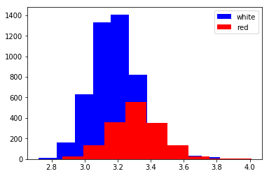

```
Text(0.5,1,u'chlorides')
```

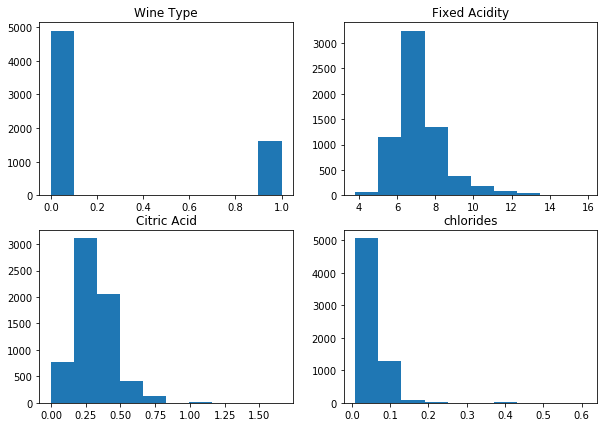

```python
datared['winetype'] = 1
datawhite['winetype'] = 0
data = pd.concat([datawhite,datared])
data.head()

# Q2.1
plt.hist(data.pH[data.winetype == 0],color="blue",label = "white")
plt.hist(data.pH[data.winetype == 1],color="red",label = "red")
plt.legend()
plt.show()

fig = plt.figure(figsize=(10,7))

ax1 = fig.add_subplot(221)
ax1.hist(data['winetype'])
ax1.set_title("Wine Type")

ax2 = fig.add_subplot(222)
ax2.hist(data['fixed acidity'])
ax2.set_title("Fixed Acidity")

ax3 = fig.add_subplot(223)
ax3.hist(data['citric acid'])
ax3.set_title("Citric Acid")

ax4 = fig.add_subplot(224)
ax4.hist(data['chlorides'])
ax4.set_title("chlorides")
```

# Q2.2

```python
y = data.winetype
X = data.loc[:, data.columns != 'winetype']
X_train, X_test, y_train, y_test = train_test_split(X, y, random_state=0)
X_train.info()

## Scaling data
from sklearn.preprocessing import StandardScaler
Xss = StandardScaler()
X_s = Xss.fit_transform(X)
X_s = pd.DataFrame(X_s,columns=X.columns)
y_s = y.values.reshape((-1,1))

## Splitting scaled dataset
X_train_s, X_test_s, y_train_s, y_test_s = train_test_split(X_s, y_s, random_state=42)
```

```
<class 'pandas.core.frame.DataFrame'>
Int64Index: 4872 entries, 3731 to 2732
Data columns (total 12 columns):
fixed acidity           4872 non-null float64
volatile acidity        4872 non-null float64
citric acid             4872 non-null float64
residual sugar          4872 non-null float64
chlorides               4872 non-null float64
free sulfur dioxide     4872 non-null float64
total sulfur dioxide    4872 non-null float64
density                 4872 non-null float64
pH                      4872 non-null float64
sulphates               4872 non-null float64
alcohol                 4872 non-null float64
quality                 4872 non-null int64
dtypes: float64(11), int64(1)
memory usage: 494.8 KB
```

```python
# Logistic regression

import statsmodels.api as sm
import pylab as pl
from sklearn.linear_model import LogisticRegression

## Fitting on unscaled dataset
lr = LogisticRegression(C=1e9)
lr.fit(X_train, y_train)
y_pred = lr.predict(X_test) # y_pred includes your predictions
#Print accuracy rounded to two digits to the right of decimal
print("accuracy: {:.5f}".format(lr.score(X_test, y_test)))


#Cross validation accurace
print(np.mean(cross_val_score(logreg, X_train, y_train,scoring='accuracy', cv=5)))
```

```
accuracy: 0.98892
0.9669534957678192
```

```python
# Penalized logistic regression

## Fitting on unscaled dataset
logregpen = LogisticRegression(C=.01)  ##  L1 Norm Penalty
model = logregpen.fit(X_train, y_train)
#Print accuracy rounded to two digits to the right of decimal
print("accuracy: {:.5f}".format(model.score(X_test, y_test)))

#Cross validation accurace
print(np.mean(cross_val_score(logregpen, X_train, y_train,scoring='accuracy', cv=5)))
```

```
accuracy: 0.95015
0.9495081133639921
```

```python
# KNN

## Fitting on scaled dataset

## KNN classification
knn = KNeighborsClassifier(n_neighbors=9)
knnmodel = knn.fit(X_train_s, y_train)

#Print accuracy rounded to two digits to the right of decimal
print("accuracy: {:.5f}".format(knnmodel.score(X_test_s, y_test)))

#Cross validation accurace
print(np.mean(cross_val_score(knn, X_train_s, y_train,scoring='accuracy', cv=5)))
```

```
accuracy: 0.74708
0.7282479827451982
```

# Q2.3, 2.4

```python
## GridSearchCV using pipeline approach. It's not necessary, but it cleans up code.

pKNN = Pipeline([("scale",StandardScaler()),("KNN",KNeighborsClassifier())])
k = np.arange(3,21,2)

#Note the call to step name "KNN__" below from the pipeline.  Need to add double underscore.
para_gs = {"KNN__n_neighbors" : k}
gs_KNN = GridSearchCV(estimator=pKNN,param_grid=para_gs,cv=10)
knngridmodel = gs_KNN.fit(X_train,y_train)
```

```python
print("accuracy: {:.4f}".format(knngridmodel.score(X_test, y_test)))
print(knngridmodel.best_params_)
```

```
accuracy: 0.9926
{'KNN__n_neighbors': 3}
```

```python
# change CV strategy, but note that I am not doing precisely what I ask you to do in the homework.
## Using GridSearchCV
from sklearn.model_selection import RepeatedKFold
rkf = RepeatedKFold(n_splits=10, n_repeats=10)

pKNN = Pipeline([("scale",StandardScaler()),("KNN",KNeighborsClassifier())])
k = np.arange(3,21,2)
para_gs = {"KNN__n_neighbors" : k}
gs_KNN = GridSearchCV(estimator=pKNN,param_grid=para_gs,cv=rkf)
knngridmodel = gs_KNN.fit(X_train,y_train)
```

```python
print("accuracy: {:.4f}".format(knngridmodel.score(X_test, y_test)))
print(knngridmodel.best_params_)
```

```
accuracy: 0.9926
{'KNN__n_neighbors': 3}
```

```python
## GridSearchCV for penalized log regression

#Note the call to step name "KNN__" below from the pipeline.  Need to add double underscore.
para_gs = {"C" :[.01,.05,1,10]}
gs_LOG= GridSearchCV(LogisticRegression(),param_grid=para_gs,cv=10)
loggridmodel = gs_LOG.fit(X_train,y_train)
```

```python
print("accuracy: {:.4f}".format(loggridmodel.score(X_test, y_test)))
print(loggridmodel.best_params_)
```

```
accuracy: 0.9883
{'C': 10}
```

# Q2.5